# Assignment

Sibylle

2023-06-06

# 1 Wheat production volumes

## 1.1 Input data

In order to calculate wheat production volumes in 2005, we use the following two datasets:

- SPAM2005V3r2_global_Y_TA_WHEA_A: a raster of the wheat yields in Kg/Ha
- SPAM2005V3r2_global_H_TA_WHEA_A: a raster of the wheat harvested areas in Ha

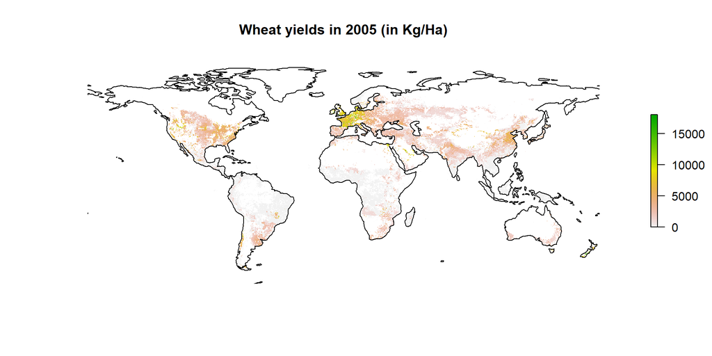

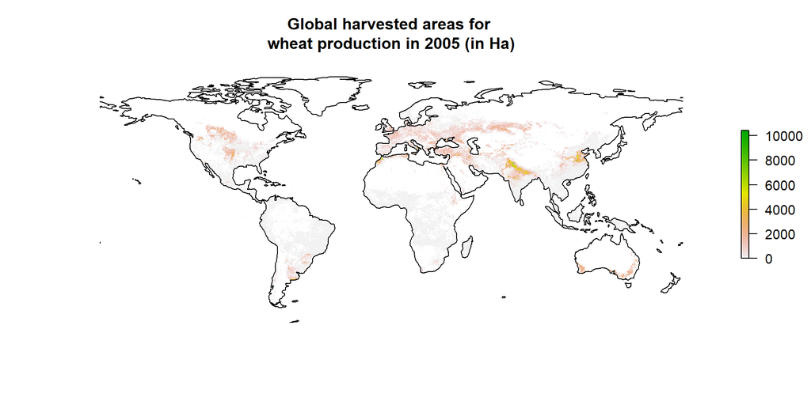

```r
SPAM_data_folder_path <- "../data/SPAM_2005_v3.2/"

#SPAM_A_data <- raster(glue::glue(SPAM_data_folder_path, "SPAM2005V3r2_global_A_TA_WHEA_A.tif"))
SPAM_Y_data <- raster(glue::glue(SPAM_data_folder_path, "SPAM2005V3r2_global_Y_TA_WHEA_A.tif"))
SPAM_H_data <- raster(glue::glue(SPAM_data_folder_path, "SPAM2005V3r2_global_H_TA_WHEA_A.tif"))

# plot(SPAM_A_data, main="Global physical areas for \nwheat production in 2005 (in Ha)",
#      axes=FALSE, box=FALSE, col=terrain.colors(4))
plot(SPAM_Y_data,  main="Wheat yields in 2005 (in Kg/Ha)",
     axes=FALSE, box=FALSE)
plot(ne_coastline(), add=TRUE)
plot(SPAM_H_data,  main="Global harvested areas for \nwheat production in 2005 (in Ha)",
     axes=FALSE, box=FALSE)
plot(ne_coastline(), add=TRUE)
```

## 1.2 Results

The resulting map is obtained by multiplying the two rasters, using the following definition of yield:
$$Yield = Production / Area_{harvested}$$

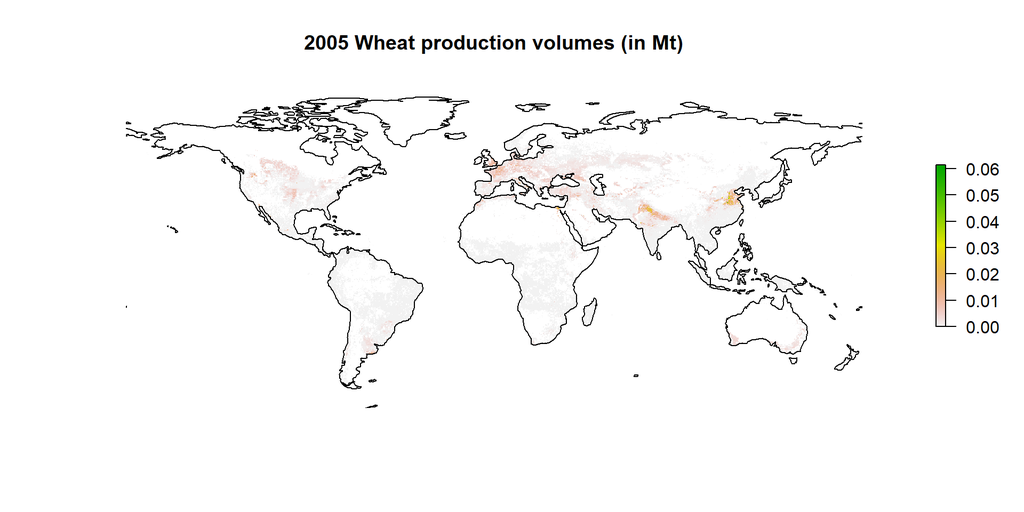

```r
SPAM_P_data <- (SPAM_H_data*SPAM_Y_data)/1000000000

plot(SPAM_P_data,
     main='2005 Wheat production volumes (in Mt)' ,
     axes=FALSE, box=FALSE)
plot(ne_coastline(), add=TRUE)
```

```r
writeRaster(SPAM_P_data,'../Assignment/SPAM2005V3r2_global_P_TA_WHEA_A.tif',
            options=c('TFW=YES'),
            overwrite=TRUE)

total_production_wheat <- signif(cellStats(SPAM_P_data, sum), 3)
```

> In 2005, 619 Mt of wheat have been harvested globally.

# 2 Wheat production per country

In order to get the wheat production per country, we layer the wheat production data raster and a vector of country boundaries (g2015_2005_2.shp). We can then extract the data within the country boundaries with the extract function.

```r
GAUL_data_folder_path <- "../data/GAUL/"
GAUL_boundaries <- vect(glue::glue(GAUL_data_folder_path, "g2015_2005_2.shp"))

GAUL_data <- as.data.frame(GAUL_boundaries)
GAUL_data$extract_GAUL <- terra::extract(rast(SPAM_P_data), GAUL_boundaries, 'sum', na.rm=TRUE, ID=FALSE)

production_per_country <- GAUL_data %>%
  group_by(ADM0_CODE, ADM0_NAME) %>%
  summarise(Production_in_Mt = sum(extract_GAUL$layer, na.rm = TRUE)) %>%
  ungroup()%>%
  dplyr::select("Country" = "ADM0_NAME", "Production_in_Mt") %>%
  arrange(desc(Production_in_Mt))
```

**Table: Wheat production per country (in Mt)**

```r
production_per_country %>% mutate(Production_in_Mt = signif(Production_in_Mt, digits = 3))
```

| Country | Production_in_Mt |
| --- | --- |
| China | 9.93e+01 |
| India | 6.96e+01 |
| United States of America | 5.51e+01 |
| Russian Federation | 4.60e+01 |
| France | 3.73e+01 |
| Canada | 2.53e+01 |
| Germany | 2.38e+01 |
| Pakistan | 2.09e+01 |
| Turkey | 2.09e+01 |
| Australia | 1.93e+01 |

[output cut: 263 more lines]

```r
write.csv(production_per_country , 'production_per_country.csv')
```

# 3 N output in harvested wheat yield

It is assumed that 2% of harvested wheat yield consists of nitrogen (N) element. Using the wheat production raster from Question 1, the N yield can be calculated using the following formula:
$$N_{yield} = (Production / Area_{harvested})*0.02$$
But we could have also directly used the provided wheat yield raster (SPAM2005V3r2_global_Y_TA_WHEA_A).

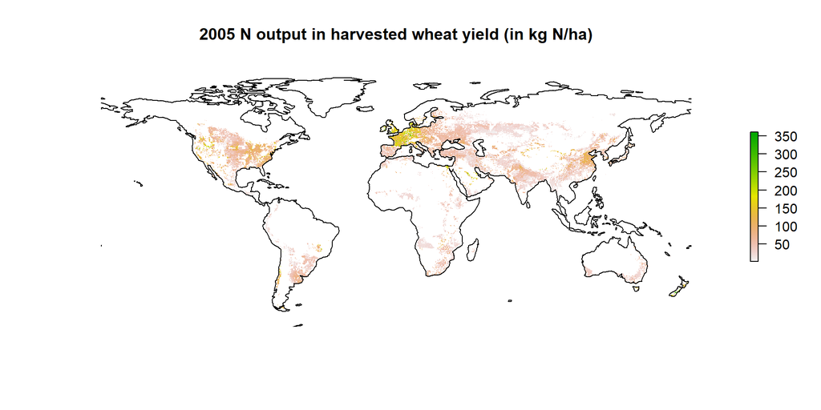

```r
N_output_yield <- (SPAM_P_data/SPAM_H_data * 0.02) * 1000000000

plot(N_output_yield, main='2005 N output in harvested wheat yield (in kg N/ha)',
     axes=FALSE, box=FALSE)
plot(ne_coastline(), add=TRUE)
```

```r
writeRaster(N_output_yield,'../Assignment/N_output_in_harvested_wheat_yield.tif',options=c('TFW=YES'), overwrite=TRUE)
```

# 4 N inputs and losses of the 10 largest wheat producers

## 4.1 Input data

In order to calculate the N inputs and losses of the 10 largest wheat producers, the following input data are used:

- Wheat production per country (Question 2)
- Nitrogen Use Efficiency (NUE)

The following graph displays the Nitrogen Use Efficiency for the top 10 wheat producing countries.

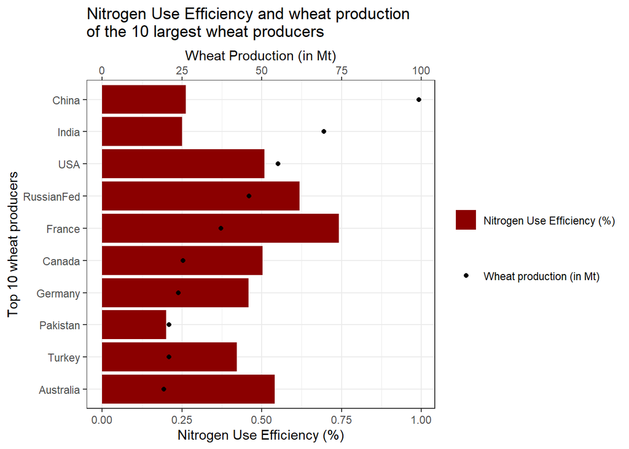

```r
country_NUE_assumptions <- read.csv("../data/NUE_Zhang_et_al_2015/Country_NUE_assumption.csv")

Nitrogen_data_per_country <- production_per_country %>%
  arrange(desc(Production_in_Mt)) %>%
  head(10)  %>%
    mutate(Country= case_when(
      Country=="United States of America" ~ "USA",
      Country == "Russian Federation" ~ "RussianFed",
      TRUE ~ Country
    )) %>%
  left_join(country_NUE_assumptions, by = "Country")

ggplot(Nitrogen_data_per_country %>% dplyr::select(Country, NUE, Production_in_Mt))+
  geom_col( aes(y=NUE,
               x=reorder(Country, Production_in_Mt),
               fill="Nitrogen Use Efficiency (%)"))+
  coord_flip()+ scale_fill_manual(values = "darkred") +
  geom_point(mapping=aes(y=Production_in_Mt/100,
                         x=Country, shape="Wheat production (in Mt)")) +
  scale_y_continuous(
    name = "Nitrogen Use Efficiency (%)",
    sec.axis = sec_axis(~.*100, name="Wheat Production (in Mt)")
  )+
  labs(y="Nitrogen Use Efficiency (%)",
       x="Top 10 wheat producers",
       title = "Nitrogen Use Efficiency and wheat production \nof the 10 largest wheat producers",
       shape=NULL, fill=NULL)+
  theme_bw()+
  guides(fill = guide_legend(order = 1),
         shape = guide_legend(order = 2))
```

## 4.2 Results

Following the assumption from previous question, we can calculate the N outputs in harvested wheat (in kg N). Then with the Nitrogen Use Efficiency (NUE) data, the N inputs are computed. Lastly, N losses are calculated as the difference between N inputs and N outputs.

$$N_{output} = Production * 0.02$$
$$N_{inputs} = N_{output} / NUE$$
$$N_{losses} = N_{inputs} - N_{output}$$

[figure not shown]

```r
Nitrogen_data_per_country <- Nitrogen_data_per_country %>%
  mutate(N_outputs_in_Tg = 0.02*Production_in_Mt,
         N_inputs_in_Tg = N_outputs_in_Tg/NUE,
         N_losses_in_Tg = N_inputs_in_Tg - N_outputs_in_Tg)

write.csv(Nitrogen_data_per_country , 'Nitrogen_data_per_country.csv')

ggplot(Nitrogen_data_per_country %>% pivot_longer(cols=c(4:6),names_to = "Type", values_to = "Values") %>%
         filter(Type != "N_inputs_in_Tg"))+
  geom_col(position="dodge", aes(y=Values, x=reorder(Country, Production_in_Mt), fill=Type))+
  coord_flip()+
  scale_fill_discrete(name="N outputs and losses (Tg)", labels = c("N outputs (Tg)", "N losses (Tg)"))+
  geom_point( mapping=aes(y=Production_in_Mt/10, x=Country, shape="Wheat production (in Mt)")) +
  scale_y_continuous(
    name = "N outputs and losses (in Tg)",
    sec.axis = sec_axis(~.*10, name="Wheat Production (in Mt)")
  )+
  labs(y="N outputs and losses (in Tg)",
       x="Top 10 wheat producers",
       title = "N outputs and losses for wheat \nproduction for the top 10 producers",
       shape=NULL, fill=NULL)+
  theme_bw()+
  guides(fill = guide_legend(order = 1),
         shape = guide_legend(order = 2))
```

```r
ggsave(filename = "Wheat_N_outputs_and_losses.pdf")
```

# 5 Integration into BNR’s modelling suite

One could for example use this analysis to assess the impact of different agricultural management practices on Nitrogen outputs and losses. However, specific Nitrogen information for each agricultural practice would be needed. The underlying assumptions, such as the 2% Nitrogen in harvested wheat yield would need to be refined. Furthermore, yield and harvesting area data for multiple years would have to be obtained (to avoid drawing conclusions based on a year that might be affected by extreme weather conditions). From my understanding this type of analysis could be performed and refined by the EPIC Model.

The Nitrogen cycle could also be integrated into the GLOBIOM model, which, by combining it to supply and demand data, could allow to see the impact of different nitrogen mitigation options on food security, as it has been done in [Chang, J. et al 2021](https://www.nature.com/articles/s43016-021-00366-x).

# 6 Issues & Assumptions

Regarding the units of the SPAM raster data, I used the same units as the units described in the technical documents (Table 2-1). Regarding the Production data calculations, I assumed that the yield data refers to the tonnes produced per harvested area, and not per physical area, also based on the SPAM technical documents. Comparing the results with FAOSTAT data confirmed both of these assumptions.

For the calculation of the production per country, I manually added correspondences(in the script) between “USA” and “United States of America”, and “Russian Federation” and “Russian Fed” in order to match the NUE to the top 10 producing countries. If the analysis would be performed on a larger data set, a proper concordance table should be implemented.

Additionally, when comparing the total production before and after the allocation per country, a difference of 0.7% is observed. This is probably due to the way the extraction is performed in the extract function. Due to time constraint and runtime limitation, this has not been further investigated. However, for some countries this could potentially lead to increased errors.